# ITMD-514, HW5

Twinkle Joshi, tjoshi3@hawk.iit.edu

### 1.Explore the t-value and the t distribution

**i) What does t0.975 = −2.145 mean? Assume that T is a random variable that follows a t-distribution with n − 1 = 14 degrees of freedom**

The correct answer for this question is- T takes values ≥ −2.145 exactly 97.5% of the time. The reason why this is the correct answer justified below- Lets take a sample size 14 having normal distribution. We pick a value 0.025 that is a known as a α value which is located on the right of the graph(normal distribution) and on the left we have t(1-α)= -tα. So we have (1-0.025) that is equal to 0.975 and the value of 0.975=-2.145 and this says that the value -2.145 or greater will happen 97.5% times. Also we know that t distribution is centered around 0

**ii) Please make sure to use the tdist function in R to check the t-value of −2.145. For example,you can use tigerstats package to plot the t-distribution and the value of $t0.975. Doing this will help you visualize your answer, rather than just memorize it.**

```r
library(tigerstats)
t.value<-qt(.975,df=14,lower.tail=F)
t.value
```

```
## [1] -2.144787
```

**iii) What happens if you change the degrees of freedom to, say, n − 1 = 140? Does the probability corresponding to the t-value go up or down? [You could, for example, plot the same plot as above, but just change n.]**

When the degrees of freedom is changed, we get a change in the t-value and The probability goes up.Also, more the number of degrees of freedom, the more t-distribution resembles to the normal distribution.

```r
t.value<-qt(.975,df=140,lower.tail=F)
t.value
```

```
## [1] -1.977054
```

### 2. Review the approach to location problems for one and two populations+

**i) For inference on population mean, which of the following could we potentially use?**

We can use the normal distribution (with the Z statistic) and the t-distribution (with the T statistic). To find inference on population mean we need several assumption like randomness, large sample size,population mean, and population standard deviation. When all these conditions are met, we use z-statistics but many a times we don’t have population standard deviation and have small sample size that’s when we use t-distribution for inference on population mean.

**ii) For inference on population mean when population variance is known, which of the following should we use? (In this part, suppose X_1, . . . , X_1000 is a random sample (of size 1000) from some unknown distribution.)**

The normal distribution with the z statistic is used when the variances are known. Therefore the right answer for this question is, The normal distribution (with the Z statistic). This answer is justified by central limit theorem which says that it doesn’t matter what X is, sample mean is distributed normally centered around the mean.Central limit theorem doesn’t require if X comes from a normal distribution.

**iii) For inference on population mean when population variance is unknown, which of the following should we use? (In this part, suppose X_1, . . . , X_1000 is a random sample (of size 1000) from some unknown distribution.)**

The t- distribution with T statistics is used when the population variance is unknown.The correct answer is, The t-distribution (with the T statistic), but ONLY if X comes from a normal distribution. The answer comes from the theorem which say the independent random variables are all normal with mean µ and standard deviation σ.

**iv) Here is a small data problem on this topic: A maker of a certain brand of low-fat cereal bars claims that the average saturated fat content is 0.5 gram. In a random sample of 8 cereal bars of this brand, the saturated fat content was 0.6, 0.7, 0.7, 0.3, 0.4, 0.5, 0.4, and 0.2. Would you agree with the claim? Assume a normal distribution.**

I think the claim is true since the values lies within 95% confidence interval.

```r
x<-c(0.6, 0.7, 0.7, 0.3, 0.4, 0.5, 0.4, 0.2)
mean(x)              # mean of the sample
```

```
## [1] 0.475
```

```r
sd(x)                # Stnadard deviation of sample
```

```
## [1] 0.1832251
```

```r
get.T.value <- function(sample.size, mu, sigma)
{
  t.value<-(mean(x)-mu)/(sd(x)/sqrt(sample.size))
  t.value
                                                              #Source code from Professor's lecture
  }
my.mu = 0.5                                    #population mean
my.sigma = 0.183
my.sample.size = 8
get.T.value(sample.size=my.sample.size,mu=my.mu,sigma=my.sigma)
```

```
## [1] -0.3859225
```

```r
t.value<-qt(.025,df=7,lower.tail=F)
t.value
```

```
## [1] 2.364624
```

**v) If you are interested in a difference of means between two populations, what should you keep in mind? [Select all that apply.] (Suppose X_1, . . . , X_1000 is a random sample (of size 1000) from one population, and Y_1, . . . , Y_500 a random sample (of size 500) from another population. )**

The correct answer is,Difference of means X − Y is approximately normal, after rescaling, but since sample sizes are large enough, we can use Z. The theorem from book states that two independent sample size and random variables from the population with different means an variances, then the difference of mean is distributed normally.

### 3. Checking out some small data sets that come with R

**Problem Assuming that the data in mtcars follows the normal distribution, let us look for whether the difference between the mean gas mileage of manual and automatic transmissions seems to be statistically significant.1 To solve the problem using the tools we have learned, you may assume that the true population standard deviation for the automatic transmission cars is 4 and for manual transmission is 6**

```r
data(mtcars)
mtcars
```

```
##                      mpg cyl  disp  hp drat    wt  qsec vs am gear carb
## Mazda RX4           21.0   6 160.0 110 3.90 2.620 16.46  0  1    4    4
## Mazda RX4 Wag       21.0   6 160.0 110 3.90 2.875 17.02  0  1    4    4
## Datsun 710          22.8   4 108.0  93 3.85 2.320 18.61  1  1    4    1
## Hornet 4 Drive      21.4   6 258.0 110 3.08 3.215 19.44  1  0    3    1
## Hornet Sportabout   18.7   8 360.0 175 3.15 3.440 17.02  0  0    3    2
## Valiant             18.1   6 225.0 105 2.76 3.460 20.22  1  0    3    1
## Duster 360          14.3   8 360.0 245 3.21 3.570 15.84  0  0    3    4
## Merc 240D           24.4   4 146.7  62 3.69 3.190 20.00  1  0    4    2
## Merc 230            22.8   4 140.8  95 3.92 3.150 22.90  1  0    4    2
## Merc 280            19.2   6 167.6 123 3.92 3.440 18.30  1  0    4    4
## Merc 280C           17.8   6 167.6 123 3.92 3.440 18.90  1  0    4    4
## Merc 450SE          16.4   8 275.8 180 3.07 4.070 17.40  0  0    3    3
## Merc 450SL          17.3   8 275.8 180 3.07 3.730 17.60  0  0    3    3
## Merc 450SLC         15.2   8 275.8 180 3.07 3.780 18.00  0  0    3    3
## Cadillac Fleetwood  10.4   8 472.0 205 2.93 5.250 17.98  0  0    3    4
## Lincoln Continental 10.4   8 460.0 215 3.00 5.424 17.82  0  0    3    4
## Chrysler Imperial   14.7   8 440.0 230 3.23 5.345 17.42  0  0    3    4
## Fiat 128            32.4   4  78.7  66 4.08 2.200 19.47  1  1    4    1
## Honda Civic         30.4   4  75.7  52 4.93 1.615 18.52  1  1    4    2
## Toyota Corolla      33.9   4  71.1  65 4.22 1.835 19.90  1  1    4    1
## Toyota Corona       21.5   4 120.1  97 3.70 2.465 20.01  1  0    3    1
## Dodge Challenger    15.5   8 318.0 150 2.76 3.520 16.87  0  0    3    2
## AMC Javelin         15.2   8 304.0 150 3.15 3.435 17.30  0  0    3    2
## Camaro Z28          13.3   8 350.0 245 3.73 3.840 15.41  0  0    3    4
## Pontiac Firebird    19.2   8 400.0 175 3.08 3.845 17.05  0  0    3    2
## Fiat X1-9           27.3   4  79.0  66 4.08 1.935 18.90  1  1    4    1
## Porsche 914-2       26.0   4 120.3  91 4.43 2.140 16.70  0  1    5    2
## Lotus Europa        30.4   4  95.1 113 3.77 1.513 16.90  1  1    5    2
## Ford Pantera L      15.8   8 351.0 264 4.22 3.170 14.50  0  1    5    4
## Ferrari Dino        19.7   6 145.0 175 3.62 2.770 15.50  0  1    5    6
## Maserati Bora       15.0   8 301.0 335 3.54 3.570 14.60  0  1    5    8
## Volvo 142E          21.4   4 121.0 109 4.11 2.780 18.60  1  1    4    2
```

```r
mtcars$mpg
```

```
##  [1] 21.0 21.0 22.8 21.4 18.7 18.1 14.3 24.4 22.8 19.2 17.8 16.4 17.3 15.2 10.4
## [16] 10.4 14.7 32.4 30.4 33.9 21.5 15.5 15.2 13.3 19.2 27.3 26.0 30.4 15.8 19.7
## [31] 15.0 21.4
```

```r
auto<-mean(mtcars$mpg)
auto
```

```
## [1] 20.09062
```

```r
mtcars$am
```

```
##  [1] 1 1 1 0 0 0 0 0 0 0 0 0 0 0 0 0 0 1 1 1 0 0 0 0 0 1 1 1 1 1 1 1
```

```r
manual<-mean(mtcars$am)
manual
```

```
## [1] 0.40625
```

```r
L = mtcars$am == 0
mpg.auto = mtcars[L,]$mpg
mpg.auto
```

```
##  [1] 21.4 18.7 18.1 14.3 24.4 22.8 19.2 17.8 16.4 17.3 15.2 10.4 10.4 14.7 21.5
## [16] 15.5 15.2 13.3 19.2
```

```r
mpg.manual = mtcars[!L,]$mpg
mpg.manual
```

```
##  [1] 21.0 21.0 22.8 32.4 30.4 33.9 27.3 26.0 30.4 15.8 19.7 15.0 21.4
```

```
##
##
## Inferential Procedures for the Difference of Two Means mu1-mu2:
##  (Welch's Approximation Used for Degrees of Freedom)
##  Results from summary data.
##
##
## Descriptive Results:
##
## group   mean      sd        n
## Group 1 20.090    4.000     19
## Group 2 0.400     6.000     13
##
##
## Inferential Results:
##
## Estimate of mu1-mu2:  19.69
## SE(x1.bar - x2.bar):  1.9
##
## 95% Confidence Interval for mu1-mu2:
##
##           lower.bound         upper.bound
##           15.715598           23.664402
##
## Test of Significance:
##
##  H_0:  mu1-mu2 = 0
##  H_a:  mu1-mu2 != 0
##
##  Test Statistic:     t = 10.36
##  Degrees of Freedom:   19.22
##  P-value:        P = 2.63e-09
```

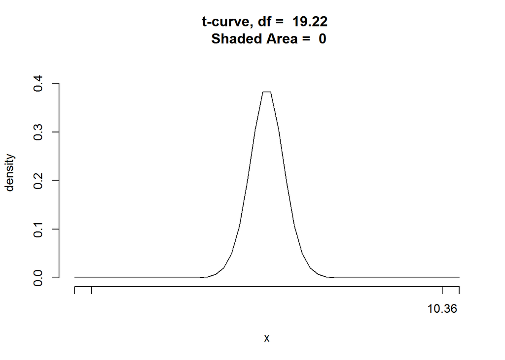

```r
ttestGC(mean=c(20.09,0.40),sd=c(4,6),n=c(19,13), mu=0, graph=TRUE) #Function Source from Google
```

### 4.Review the approach to scale problems for one and two populations

**i) For inference on population variance, which of the following distributions will be useful?**

If we have S2 as a variance of random sample size n from normal population having the variance of σ2, then we have statistics χ2 = (n − 1) S2/ σ2 And this statistics follows chi square distribution with n-1 degrees of freedom. The interval estimation of the chi square distribution for 95% of its distribution is between n χ2 0.975 and χ2 0.025. So we conclude that for inference on population variance, we use chi square distribution which is denoted by χ2. Source (Taken theorem from book)

**ii) For comparing variances between two populations, which of the following distributions will be useful?**

For comparing variances between two populations, we use F distributions. When there are two or more samples, it is easy to compare the variance using F distribution. The theorem for F distribution states that when we have two independent variables with chi square distribution and having respective degrees of freedom then the distribution of random variable is given by F distribution.

**iii) Why do we use a quantile plot? [Select all that apply.]** We use quantile plot because of these reasons Because we always need to ensure the data come from a normal population. and To make inference about a statistic: for example, we need to check if the sample variance follows a normal distribution.

### 5. Functions

**i) Write a function in R to do this**

```r
library(ggplot2)
bank_marketing_training <- read.csv("H:/RStudio/age_marital.csv")
bank_marketing_training
```

```
##       X age  marital
## 1     0  56  married
## 2     1  57  married
## 3     2  41  married
## 4     3  25   single
## 5     4  29   single
## 6     5  57 divorced
## 7     6  35  married
## 8     7  39   single
## 9     8  30  married
## 10    9  55   single
## 11   10  41   single
## 12   11  37  married
## 13   12  35  married
## 14   13  46  married
```

[output cut: 97 more lines]

```r
mean_of_age <- function(age,n){
  age<-sum(age)
result <- age/n
print(result)
}
age<-(bank_marketing_training [,2])
mean_of_age(age,111)
```

```
## [1] 44.08108
```